# Multiple Comparisons HW1

Andrey Kravets

06.11.2024

# Задание

Есть ли разница между средним ростом футболистов, играющих на разных позициях? 1. Постройте доверительные интервалы для попарных разниц между средними (без поправок и с поправкой Бонферрони). Покрывают ли интервалы реальную разницу между средним ростом? Иллюстрации приветствуются. 2. Проведите попарные тесты для разниц между средними (без поправок, с поправкой Холма и поправкой Бенджамини-Хохберга). Сколько открытий получилось в каждом случае? Сколько из них ложные?

Hint: вам может пригодиться функция pairwise.t.test. Hint 2: параметр задайте параметр pool.sd = FALSE.

## Подготовка

Let’s state alpha = 0.05

```r
summary(soccer_wrk)
```

```
##      Name                 Position       Nationality      Age
##  Length:50          Defender  :18   Argentinian: 7   Min.   :19.0
##  Class :character   Forward   :16   English    :11   1st Qu.:24.0
##  Mode  :character   Goalkeeper: 5   German     : 6   Median :27.0
##                     Midfielder:11   Italian    :11   Mean   :26.9
##                                     Spanish    :15   3rd Qu.:30.0
##                                                      Max.   :37.0
##      Height
##  Min.   :165.0
##  1st Qu.:179.0
##  Median :183.0
##  Mean   :183.2
##  3rd Qu.:188.0
##  Max.   :201.0
```

```r
standardize_groups <- function(tbl) {
  tbl %>%
    mutate(
      new_group1 = if_else(group1 < group2, group1, group2),
      new_group2 = if_else(group1 < group2, group2, group1)
    ) %>%
    select(-group1, -group2) %>%
    rename(group1 = new_group1, group2 = new_group2)
}
```

```r
general_stats = soccer_general %>%
  group_by(Position) %>%
  summarise(
    Mean_Height = mean(Height),
    SD = sd(Height),
    N = n(),
    #SEM = SD / sqrt(N)
  )

general_pairwise_combinations <- combn(general_stats$Position, 2, simplify = FALSE) %>%
  map_df(~ tibble(group1 = .x[1], group2 = .x[2]))

gen_pairwise_stats <- general_pairwise_combinations %>%
  left_join(general_stats, by = c("group1" = "Position")) %>%
  rename(mean1 = Mean_Height, N1=N, SD1=SD) %>%
  left_join(general_stats, by = c("group2" = "Position")) %>%
  rename(mean2 = Mean_Height, N2=N, SD2=SD) %>%
  mutate(group1=as.character(group1), group2=as.character(group2)) %>%
  standardize_groups(.) %>%
  mutate(gen_mean_diff = mean1-mean2, gen_diff_SE=sqrt((SD2**2)/N2+(SD1**2)/N1)) %>%
  select(group1, group2, gen_mean_diff, gen_diff_SE) %>%
  mutate(CI_low_gen = gen_mean_diff - qt(0.975, df=Inf) * gen_diff_SE,
         CI_upp_gen = gen_mean_diff + qt(0.975, df=Inf) * gen_diff_SE,)

gen_pairwise_stats
```

```
## # A tibble: 6 × 6
##   group1     group2     gen_mean_diff gen_diff_SE CI_low_gen CI_upp_gen
##   <chr>      <chr>              <dbl>       <dbl>      <dbl>      <dbl>
## 1 Defender   Forward            3.32        0.580      2.18        4.46
## 2 Defender   Goalkeeper        -5.26        0.445     -6.13       -4.38
## 3 Defender   Midfielder         4.08        0.408      3.28        4.88
## 4 Forward    Goalkeeper        -8.57        0.602     -9.76       -7.39
## 5 Forward    Midfielder         0.765       0.576     -0.363       1.89
## 6 Goalkeeper Midfielder         9.34        0.439      8.48       10.2
```

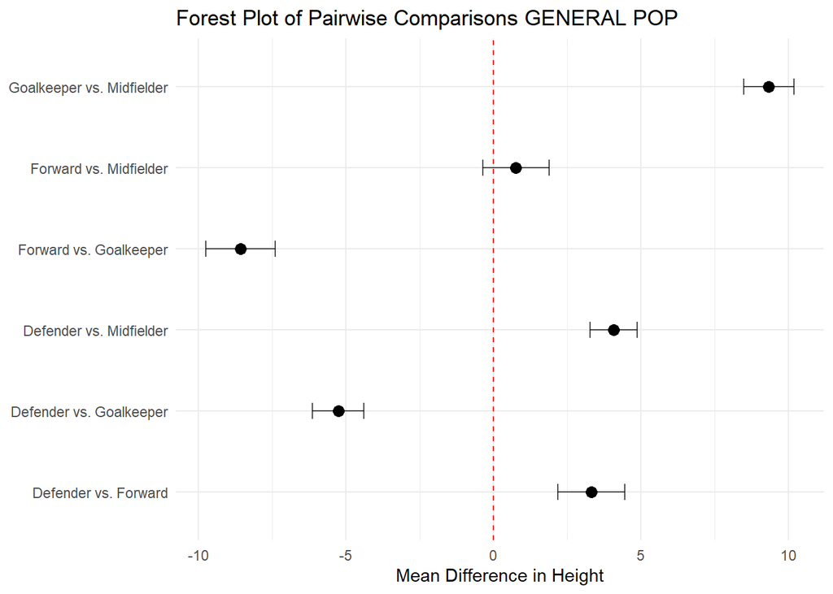

```r
gen_pairwise_stats %>% mutate(comparison=paste(group1, "vs.", group2)) %>%
  ggplot(aes(x = gen_mean_diff, y = comparison)) +
  geom_point(size = 3) +
  geom_errorbarh(
    aes(xmin = CI_low_gen, xmax = CI_upp_gen),
    height = 0.2, alpha = 0.7
  ) + geom_vline(xintercept=0, color='red', linetype='dashed') +
  labs(
    title = "Forest Plot of Pairwise Comparisons GENERAL POP",
    x = "Mean Difference in Height",
    y = "Comparison",
    color = "Confidence Interval"
  ) +
  theme_minimal() +
  theme(
    axis.title.y = element_blank(),
    legend.position = "bottom"
  )
```

Dots = Mean difference in general population. CI was made using normal distribution and SE in general population.

Видим, что в ген. совокупности много разниц на самом деле являются стат.значимыми.

# Первая часть - ДИ

## Без поправки Бонферрони

```r
group_stats <- soccer_wrk %>%
  group_by(Position) %>%
  summarise(
    Mean_Height = mean(Height),
    SD = sd(Height),
    N = n(),
    SEM = SD / sqrt(N)
  )

pairwise_results <- pairwise.t.test(
  soccer_wrk$Height,
  soccer_wrk$Position,
  p.adjust.method = "none",
  pool.sd = TRUE
) %>% broom::tidy() %>% standardize_groups(.)

pairwise_results <- pairwise_results %>%
  left_join(group_stats, by = c("group1" = "Position")) %>%
  rename(n1 = N, mean1 = Mean_Height, std1 = SD)

pairwise_results <- pairwise_results %>%
  left_join(group_stats, by = c("group2" = "Position")) %>%
  rename(n2 = N, mean2 = Mean_Height, std2 = SD)

pairwise_results <- pairwise_results %>%
  mutate(mean_difference = mean1-mean2,
                            std_mean = sqrt((std1**2)/n1 + (std2**2)/n2),
                            df = n1+n2-2) %>%
  select(group1, group2, p.value, df, mean_difference, std_mean) %>%
  mutate(
    CI_Lower = mean_difference - qt(0.975, df = df) * std_mean,
    CI_Upper = mean_difference + qt(0.975, df = df) * std_mean
  ) %>% select(group1, group2, CI_Lower, CI_Upper)
pairwise_results
```

```
## # A tibble: 6 × 4
##   group1     group2     CI_Lower CI_Upper
##   <chr>      <chr>         <dbl>    <dbl>
## 1 Defender   Forward       -1.55     8.75
## 2 Defender   Goalkeeper    -7.66     4.30
## 3 Forward    Goalkeeper   -12.8      2.23
## 4 Defender   Midfielder     3.70     9.92
## 5 Forward    Midfielder    -2.19     8.62
## 6 Goalkeeper Midfielder     2.15    14.8
```

```r
combined_table <- full_join(
  gen_pairwise_stats,
  pairwise_results,
  by = c("group1", "group2"),
  suffix = c("_gen", "_pairwise")
) %>% mutate(comparison=paste(group1, "vs.", group2))
```

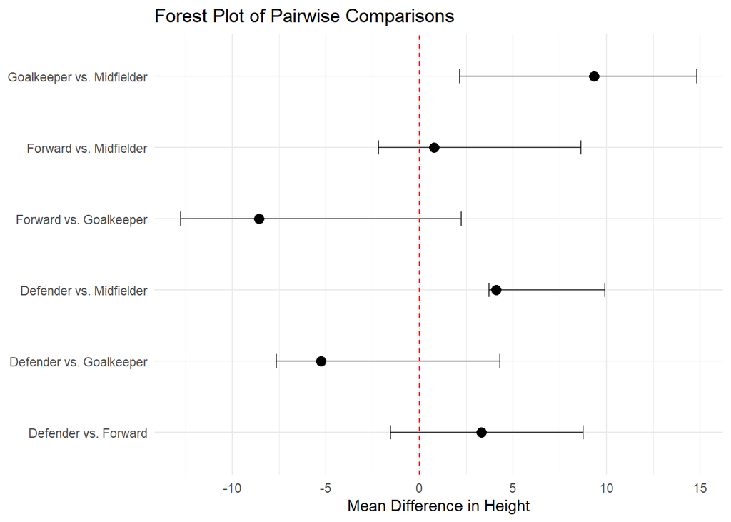

```r
ggplot(combined_table, aes(x = gen_mean_diff, y = comparison)) +
  geom_point(size = 3) +
  geom_errorbarh(
    aes(xmin = CI_Lower, xmax = CI_Upper),
    height = 0.2, alpha = 0.7
  ) + geom_vline(xintercept=0, color='red', linetype='dashed') +
  labs(
    title = "Forest Plot of Pairwise Comparisons",
    x = "Mean Difference in Height",
    y = "Comparison",
    color = "Confidence Interval"
  ) +
  theme_minimal() +
  theme(
    axis.title.y = element_blank(),
    legend.position = "bottom"
  )
```

Dots = Mean difference in general population. CI from our sample.

Итого: на самом деле, получилось, что все CI покрывают ту разницу, которую мы видим в нашей заявленной “генеральной совокупности”. Но давайте отметим что в случае Defender vs. Midfielder истинная разница очень близка к левой границе ДИ. NB! в нашей выборке 50 футболистов

Теперь посмотрим на Бонферрони. ## С поправкой Бонферрони

```r
group_stats <- soccer_wrk %>%
  group_by(Position) %>%
  summarise(
    Mean_Height = mean(Height),
    SD = sd(Height),
    N = n(),
    SEM = SD / sqrt(N)
  )

pairwise_results <- pairwise.t.test(
  soccer_wrk$Height,
  soccer_wrk$Position,
  p.adjust.method = "bonferroni",
  pool.sd = TRUE
) %>% broom::tidy()

pairwise_results <- pairwise_results %>%
  left_join(group_stats, by = c("group1" = "Position")) %>%
  rename(n1 = N, mean1 = Mean_Height, std1 = SD)

pairwise_results <- pairwise_results %>%
  left_join(group_stats, by = c("group2" = "Position")) %>%
  rename(n2 = N, mean2 = Mean_Height, std2 = SD)

pairwise_results <- pairwise_results %>% mutate(mean_difference = mean2-mean1,
                            std_mean = sqrt((std1**2)/n1 + (std2**2)/n2),
                            df = n1+n2-2) %>%
  select(group1, group2, p.value, df, mean_difference, std_mean) %>%
  mutate(
    Bonferroni_Adjusted_CI_Lower = mean_difference - qt(1 - (0.025 / 6), df = df)*std_mean,
    Bonferroni_Adjusted_CI_Upper = mean_difference + qt(1 - (0.025 / 6), df = df)*std_mean,
  ) %>% select(group1, group2, Bonferroni_Adjusted_CI_Lower, Bonferroni_Adjusted_CI_Upper)
pairwise_results
```

```
## # A tibble: 6 × 4
##   group1     group2     Bonferroni_Adjusted_CI_Lower Bonferroni_Adjusted_CI_Up…¹
##   <chr>      <chr>                             <dbl>                       <dbl>
## 1 Forward    Defender                         -3.52                        10.7
## 2 Goalkeeper Defender                        -10.1                          6.70
## 3 Goalkeeper Forward                         -15.8                          5.28
## 4 Midfielder Defender                          2.50                        11.1
## 5 Midfielder Forward                          -4.30                        10.7
## 6 Midfielder Goalkeeper                       -0.587                       17.6
## # ℹ abbreviated name: ¹Bonferroni_Adjusted_CI_Upper
```

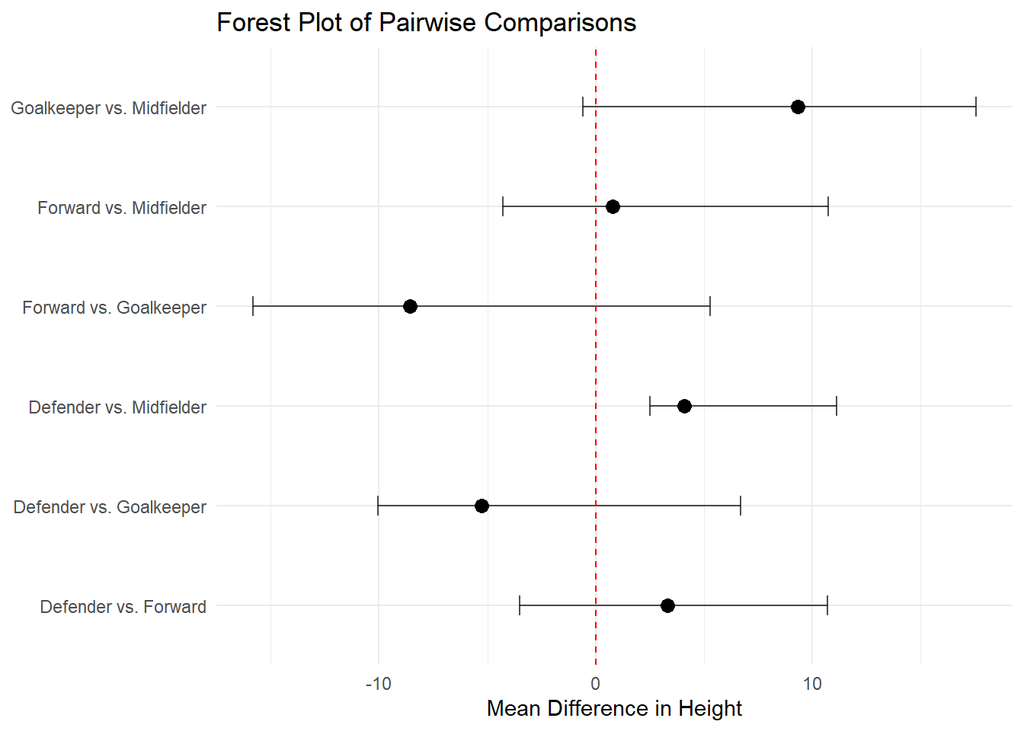

```r
pairwise_results <- standardize_groups(pairwise_results)

combined_table <- full_join(
  gen_pairwise_stats,
  pairwise_results,
  by = c("group1", "group2"),
  suffix = c("_gen", "_pairwise")
) %>% mutate(comparison=paste(group1, "vs.", group2))


ggplot(combined_table, aes(x = gen_mean_diff, y = comparison)) +
  geom_point(size = 3) +
  geom_errorbarh(
    aes(xmin = Bonferroni_Adjusted_CI_Lower,
        xmax = Bonferroni_Adjusted_CI_Upper),
    height = 0.2, alpha = 0.7
  ) + geom_vline(xintercept=0, color='red', linetype='dashed') +
  labs(
    title = "Forest Plot of Pairwise Comparisons",
    x = "Mean Difference in Height",
    y = "Comparison",
    color = "Confidence Interval"
  ) +
  theme_minimal() +
  theme(
    axis.title.y = element_blank(),
    legend.position = "bottom"
  )
```

Итого: тут у нас тоже получилось, что все CI покрывают ту разницу, которую мы видим в нашей заявленной “генеральной совокупности”. Возвращаясь к Defender vs. Midfielder - по сравнению с ДИ без поправки, теперь у нас левая граница ДИ дальше от истинной разницы.

Заметим ещё, что при сравнении Goalkeeper vs. Midfielder при нашей поправке мы перешли за 0, по сравнению с предыдущим графиком.

# Часть 2

## Без поправки

```r
pairwise_results <- pairwise.t.test(
  soccer_wrk$Height,
  soccer_wrk$Position,
  p.adjust.method = "none",
  pool.sd = TRUE
) %>% broom::tidy() %>% mutate(Significant = if_else(p.value < 0.05, TRUE, FALSE))

pairwise_results
```

```
## # A tibble: 6 × 4
##   group1     group2     p.value Significant
##   <chr>      <chr>        <dbl> <lgl>
## 1 Forward    Defender   0.110   FALSE
## 2 Goalkeeper Defender   0.608   FALSE
## 3 Goalkeeper Forward    0.116   FALSE
## 4 Midfielder Defender   0.00799 TRUE
## 5 Midfielder Forward    0.207   FALSE
## 6 Midfielder Goalkeeper 0.0180  TRUE
```

Без поправки у нас стат. значимы разницы между Midfielder vs. Defender; Midfielder vs. Goalkeeper.

## Холма

```r
pairwise_results <- pairwise.t.test(
  soccer_wrk$Height,
  soccer_wrk$Position,
  p.adjust.method = "holm",
  pool.sd = TRUE
) %>% broom::tidy() %>% mutate(Significant = if_else(p.value < 0.05, TRUE, FALSE))

pairwise_results
```

```
## # A tibble: 6 × 4
##   group1     group2     p.value Significant
##   <chr>      <chr>        <dbl> <lgl>
## 1 Forward    Defender    0.439  FALSE
## 2 Goalkeeper Defender    0.608  FALSE
## 3 Goalkeeper Forward     0.439  FALSE
## 4 Midfielder Defender    0.0479 TRUE
## 5 Midfielder Forward     0.439  FALSE
## 6 Midfielder Goalkeeper  0.0902 FALSE
```

## Бенджамини-Хохберга

```r
pairwise_results <- pairwise.t.test(
  soccer_wrk$Height,
  soccer_wrk$Position,
  p.adjust.method = "BH",
  pool.sd = TRUE
) %>% broom::tidy() %>% mutate(Significant = if_else(p.value < 0.05, TRUE, FALSE))

pairwise_results
```

```
## # A tibble: 6 × 4
##   group1     group2     p.value Significant
##   <chr>      <chr>        <dbl> <lgl>
## 1 Forward    Defender    0.173  FALSE
## 2 Goalkeeper Defender    0.608  FALSE
## 3 Goalkeeper Forward     0.173  FALSE
## 4 Midfielder Defender    0.0479 TRUE
## 5 Midfielder Forward     0.249  FALSE
## 6 Midfielder Goalkeeper  0.0541 FALSE
```

В нашем случае: получилось, что поправки “убили” стат. значимую разницу в случае Midfilder vs. Goalkeeper, но “сохранили” стат.значимость в случае Midfielder vs. Defender.

Говоря про истинность, я бы отметил следующее: если взять Midfilder vs. Goalkeeper, то по нашей “генеральной совокупности” разницы в росте между этими позициями есть и она достаточно большая. В нашей выборки без поправки т-тест “смог найти” эту разницу, но при наших поправках Холма, БХ p > 0.05 (alpha) стал и мы потеряли стат. значимость. Это показывает, что при поправках мы теряем мощность, но обезопашиваем себя от увеличения ошибки первого рода.